# An example notebook created using notestar

Updated on Tuesday, March 01, 2022 01:56 PM

TJ Mahr

Source code for demo available here: https://github.com/tjmahr/notestar-demo

## Apr. 12, 2021 (Mixed models)

Source: `2021-04-12-models.Rmd`

We fit two mixed models on the sleep dataset using brms.

One with random intercepts:

```r
library(tidyverse)
library(brms)
model_1 <- targets::tar_read(model_1)
model_2 <- targets::tar_read(model_2)
model_1
```

```
#>  Family: gaussian
#>   Links: mu = identity; sigma = identity
#> Formula: Reaction ~ Days + (1 | Subject)
#>    Data: data (Number of observations: 180)
#>   Draws: 4 chains, each with iter = 1000; warmup = 0; thin = 1;
#>          total post-warmup draws = 4000
#>
#> Group-Level Effects:
#> ~Subject (Number of levels: 18)
#>               Estimate Est.Error l-95% CI u-95% CI Rhat Bulk_ESS Tail_ESS
#> sd(Intercept)    39.20      7.35    27.30    56.13 1.00      798     1339
#>
#> Population-Level Effects:
#>           Estimate Est.Error l-95% CI u-95% CI Rhat Bulk_ESS Tail_ESS
#> Intercept   251.59     10.20   231.61   272.66 1.00      585     1159
#> Days         10.46      0.82     8.89    12.01 1.00     3901     2748
#>
#> Family Specific Parameters:
#>       Estimate Est.Error l-95% CI u-95% CI Rhat Bulk_ESS Tail_ESS
#> sigma    31.23      1.73    28.11    34.84 1.00     3480     3041
#>
#> Draws were sampled using sample(hmc). For each parameter, Bulk_ESS
#> and Tail_ESS are effective sample size measures, and Rhat is the potential
#> scale reduction factor on split chains (at convergence, Rhat = 1).
```

And one with random slopes.

```r
model_2
```

```
#>  Family: gaussian
#>   Links: mu = identity; sigma = identity
#> Formula: Reaction ~ Days + (Days | Subject)
#>    Data: data (Number of observations: 180)
#>   Draws: 4 chains, each with iter = 1000; warmup = 0; thin = 1;
#>          total post-warmup draws = 4000
#>
#> Group-Level Effects:
#> ~Subject (Number of levels: 18)
#>                     Estimate Est.Error l-95% CI u-95% CI Rhat Bulk_ESS Tail_ESS
#> sd(Intercept)          26.95      6.97    15.55    43.18 1.00     1835     2362
#> sd(Days)                6.62      1.55     4.11    10.12 1.00     1394     2015
#> cor(Intercept,Days)     0.07      0.30    -0.49     0.66 1.00     1082     1815
#>
#> Population-Level Effects:
#>           Estimate Est.Error l-95% CI u-95% CI Rhat Bulk_ESS Tail_ESS
#> Intercept   251.37      7.31   236.65   265.89 1.00     2050     2477
#> Days         10.44      1.73     7.06    13.83 1.00     1412     2051
#>
#> Family Specific Parameters:
#>       Estimate Est.Error l-95% CI u-95% CI Rhat Bulk_ESS Tail_ESS
#> sigma    25.92      1.56    23.16    29.24 1.00     3671     2728
#>
#> Draws were sampled using sample(hmc). For each parameter, Bulk_ESS
#> and Tail_ESS are effective sample size measures, and Rhat is the potential
#> scale reduction factor on split chains (at convergence, Rhat = 1).
```

```r
summary_1 <- model_1 %>%
  posterior_summary() %>%
  as_tibble(rownames = "parameter") %>%
  mutate(model = "model_1")

summary_2 <- model_2 %>%
  posterior_summary() %>%
  as_tibble(rownames = "parameter") %>%
  mutate(model = "model_2")
head(summary_2)
```

```
#> # A tibble: 6 × 6
#>   parameter                    Estimate Est.Error    Q2.5   Q97.5 model
#>   <chr>                           <dbl>     <dbl>   <dbl>   <dbl> <chr>
#> 1 b_Intercept                  251.         7.31  237.    266.    model_2
#> 2 b_Days                        10.4        1.73    7.06   13.8   model_2
#> 3 sd_Subject__Intercept         26.9        6.97   15.6    43.2   model_2
#> 4 sd_Subject__Days               6.62       1.55    4.11   10.1   model_2
#> 5 cor_Subject__Intercept__Days   0.0746     0.300  -0.489   0.659 model_2
#> 6 sigma                         25.9        1.56   23.2    29.2   model_2
```

[figure not shown]

```r
summary <- bind_rows(summary_1, summary_2) %>%
  filter(!stringr::str_detect(parameter, "^r_Subject"))

ggplot(summary) +
  aes(x = Estimate, y = model) +
  geom_pointrange(aes(xmin = Q2.5, xmax = Q97.5), position = position_dodge()) +
  facet_wrap("parameter", scales = "free_x", ncol = 2)
```

### Model comparison

As part of the build pipeline, we computed a leave-one-out information criteria (LOOIC) and LOO-weighted Bayesian R-squared statistic. Let’s look at the R2 first.

```r
loo_R2(model_1)
```

```
#>     Estimate  Est.Error      Q2.5     Q97.5
#> R2 0.6621241 0.04764755 0.5606662 0.7428179
```

```r
loo_R2(model_2)
```

```
#>     Estimate  Est.Error      Q2.5     Q97.5
#> R2 0.7457722 0.05443348 0.6222576 0.8316524
```

This comparison would favor the second model.

Let’s compare the LOOIC values. The second model has lower LOOIC values.

```r
loo(model_1)
```

```
#>
#> Computed from 4000 by 180 log-likelihood matrix
#>
#>          Estimate   SE
#> elpd_loo   -884.7 14.2
#> p_loo        19.1  3.2
#> looic      1769.3 28.4
#> ------
#> Monte Carlo SE of elpd_loo is 0.1.
#>
#> Pareto k diagnostic values:
#>                          Count Pct.    Min. n_eff
#> (-Inf, 0.5]   (good)     179   99.4%   714
#>  (0.5, 0.7]   (ok)         1    0.6%   189
#>    (0.7, 1]   (bad)        0    0.0%   <NA>
#>    (1, Inf)   (very bad)   0    0.0%   <NA>
#>
#> All Pareto k estimates are ok (k < 0.7).
#> See help('pareto-k-diagnostic') for details.
```

```r
loo(model_2)
```

```
#>
#> Computed from 4000 by 180 log-likelihood matrix
#>
#>          Estimate   SE
#> elpd_loo   -861.0 22.3
#> p_loo        34.3  8.6
#> looic      1722.0 44.6
#> ------
#> Monte Carlo SE of elpd_loo is NA.
#>
#> Pareto k diagnostic values:
#>                          Count Pct.    Min. n_eff
#> (-Inf, 0.5]   (good)     172   95.6%   835
#>  (0.5, 0.7]   (ok)         5    2.8%   1046
#>    (0.7, 1]   (bad)        2    1.1%   25
#>    (1, Inf)   (very bad)   1    0.6%   32
#> See help('pareto-k-diagnostic') for details.
```

We could report a difference.

```r
loo_compare(model_1, model_2)
```

```
#>         elpd_diff se_diff
#> model_2   0.0       0.0
#> model_1 -23.7      11.7
```

These would have to multiplied by -2 to be on the deviance scale.

Source: `2021-04-11-data-exploration.Rmd`

Let’s read in our cached dataset.

```r
library(tidyverse)
data <- targets::tar_read(sleep_data)
```

This is the `sleepstudy` dataset (Belenky et al., 2003) from the lme4 package (Bates, Mächler, Bolker, & Walker, 2015). It had repeated measurements of reaction times nested in participants.

```r
head(data)
```

```
#> # A tibble: 6 × 3
#>   Reaction  Days Subject
#>      <dbl> <dbl>   <dbl>
#> 1     250.     0     308
#> 2     259.     1     308
#> 3     251.     2     308
#> 4     321.     3     308
#> 5     357.     4     308
#> 6     415.     5     308
```

```r
count(data, Subject)
```

```
#> # A tibble: 18 × 2
#>    Subject     n
#>      <dbl> <int>
#>  1     308    10
#>  2     309    10
#>  3     310    10
#>  4     330    10
#>  5     331    10
#>  6     332    10
#>  7     333    10
#>  8     334    10
#>  9     335    10
#> 10     337    10
#> 11     349    10
#> 12     350    10
#> 13     351    10
#> 14     352    10
#> 15     369    10
#> 16     370    10
#> 17     371    10
#> 18     372    10
```

```r
count(data, Days)
```

```
#> # A tibble: 10 × 2
#>     Days     n
#>    <dbl> <int>
#>  1     0    18
#>  2     1    18
#>  3     2    18
#>  4     3    18
#>  5     4    18
#>  6     5    18
#>  7     6    18
#>  8     7    18
#>  9     8    18
#> 10     9    18
```

We can plot all the participants’ data.

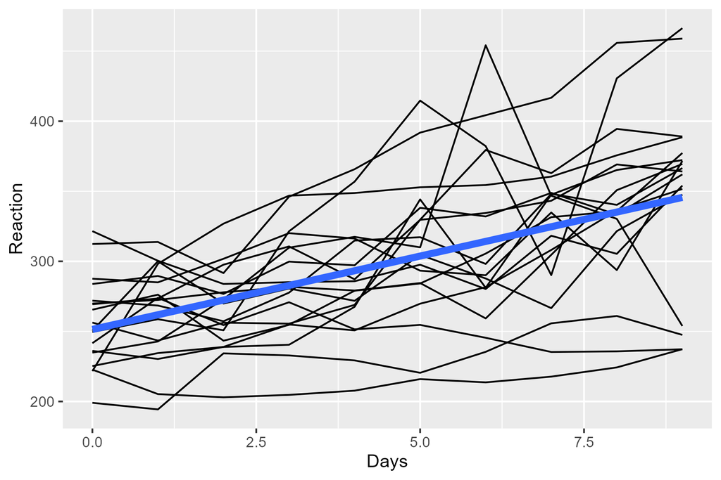

Spaghetti plot of individual participant’s data and group mean.

```r
ggplot(data) +
  aes(x = Days, y = Reaction) +
  geom_line(aes(group = Subject)) +
  stat_smooth(se = FALSE, method = "lm", size = 2, formula = y ~ x)
```

Source: `2021-04-10-about-demo.Rmd`

This note is a small demo. It should illustrate using targets to fit a model and using notestar to write up some data notes and modeling notes. It should use feature an example of using pandoc citations.

## References

Bates, D., Mächler, M., Bolker, B., & Walker, S. (2015). Fitting linear mixed-effects models using lme4. *Journal of Statistical Software*, *67*(1), 1–48. doi:10.18637/jss.v067.i01

Belenky, G., Wesensten, N. J., Thorne, D. R., Thomas, M. L., Sing, H. C., Redmond, D. P., … Balkin, T. J. (2003). Patterns of performance degradation and restoration during sleep restriction and subsequent recovery: A sleep dose-response study. *Journal of Sleep Research*, *12*(1), 1–12. doi:10.1046/j.1365-2869.2003.00337.x